# Classification Problems

# 1 Classification Problems

Variables can be characterized as either quantitative or qualitative (also known as categorical). Quantitative variables take on numerical values. Examples include a person’s age, height, or income or the value of a house. In contrast, qualitative variables take on values in one of K different classes, or categories. Examples of qualitative variables include a person’s marital status (married or not), the brand of product class purchased (brand A, B, or C) etc. We tend to refer to problems with a quantitative response as regression problems, while those involving a qualitative response are often referred to as classification problems.

Classification problems are about predicting discrete categories or labels for given inputs. Here our goal is to build up a classifier, that assigns a class label from our set `c` to a future, unlabeled observation `x` where `x` is the feature vector. We’d also like to assess the uncertainty in each classification and the roles of the different predictors amongst the x’s in producing that classify. One example is using the words in an email to classify it as legit (ham) or spam.

To graphically visualize a very simple classification problem we have a range of X values and the Y can have only two categories, which we represent here as 0 or 1. The line in the graph will be the probability of 1 given a certain X:

[figure not shown]

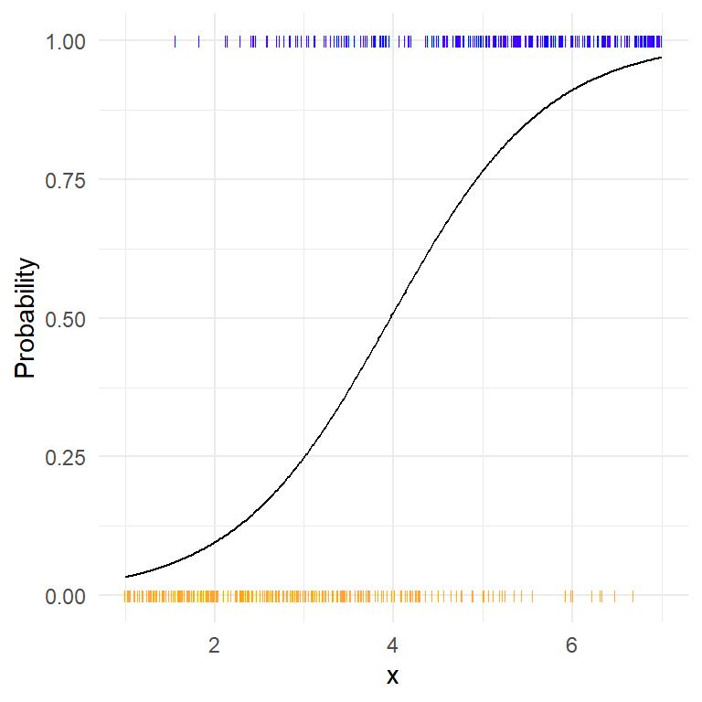

In this simple example above we only have two k elements (0 and 1) but there may be many K elements, so we express the probability of k for a given value of x like this:
$$p_k(x)=Pr(Y=k|X=x),k=1,2,\dots,K
\tag{1}$$
These are the *conditional class probabilities* at x.

The *Bayes optimal classifier* is essentially the gold standard in classification. It represents the best possible classifier that can be achieved if we had perfect knowledge of the probability distribution of the data.

Imagine it like this: if you knew the exact probability of every possible classification given all possible features, you could make the optimal decision every time. This is what the Bayes optimal classifier does. It assigns each instance to the class with the highest posterior probability.

In formula terms, if $P(CxX)$ is the posterior probability of class C given the feature X, then the Bayes optimal decision rule assigns X to the class C $C(x)=j$ if $p_j(x)=max\{p_1(x),p_2(x),\dots,p_k(x)\}$ In our example, for X=5 we know that we have around 75% probability of a 1 and 25% probability of a 0, which means that we would classify that point as a 1

In practice, we often don’t have perfect knowledge of these probabilities, so we use various methods to approximate the Bayes optimal classifier, like Naive Bayes, which assumes independence between features.

Typically we measure the performance of the classifier $\hat{C(x)}$ using the misclassification error rate{#misclassificationErrorRate}, that is the number of mistakes we make and it’s represented by the formula
$$Err_{Te}=Ave_{i\epsilon Te}I[y_i\ne\hat{C(x_i)]}
\tag{2}$$

## 1.1 Logistic regression

The formula for the logistic regression is:
$${p}(X) = \frac{e^{(\beta_0 + \beta_1 X_1 + \beta_2 X_2 + \cdots + \beta_n X_n)}}{1 + e^{(\beta_0 + \beta_1 X_1 + \beta_2 X_2 + \cdots + \beta_n X_n)}}
\tag{3}$$

This formula can also be written as:

$$log\left( \frac{p(X)}{1-p(X)} \right)=\beta_0+\beta_1X_1+\dots+\beta_nX_n
\tag{4}$$

and it is called *log odds* or *logit transformacion of p(X)*

### 1.1.1 Maximum Likelihood Estimation (MLE)

Maximum Likelihood Estimation (MLE) is used to find the parameters (coefficients) in logistic regression. Here’s the lowdown: MLE aims to find the parameter values that make the observed data most probable. It identifies the set of parameters (in our case, the regression coefficients) that maximize the likelihood function.

In Logistic Regression: For binary outcomes (0 or 1), logistic regression models the probability of the outcome. The likelihood Function: for logistic regression is:
$$L(\beta) = \prod_{i=1}^n \hat{p}(x_i)^{y_i} [1 - \hat{p}(x_i)]^{1 - y_i}
\tag{5}$$

Where: $\hat{p}(xi)$ is the predicted probability for the i-th observation. $y_i$ is the observed outcome (0 or 1) for the i-th observation.

Log-Likelihood: For computational simplicity, we usually work with the natural logarithm of the likelihood function (log-likelihood):
$$\ell(\beta) = \sum_{i=1}^n y_i \log(\hat{p}(x_i)) + (1 - y_i) \log(1 - \hat{p}(x_i))$$

Optimization: The goal is to find the parameter values (β0,β1,β2,…,βn) that maximize the log-likelihood function.

This is usually done using numerical optimization methods since there’s no closed-form solution.

Intuition: MLE in logistic regression finds the best-fit model that maximizes the probability of observing the given data.

It adjusts the coefficients to maximize the match between the predicted probabilities and the actual outcomes.

In r we use the function `glm()`

The package ISLR2 has a dataset ‘Default’ and we want to use to see what variables (student, balance(credit balance), and income) are relevant to predict if a person is going to default their credit card payments.

First we are going to see each variable independently:

```r
head(Default)
```

```
  default student   balance    income
1      No      No  729.5265 44361.625
2      No     Yes  817.1804 12106.135
3      No      No 1073.5492 31767.139
4      No      No  529.2506 35704.494
5      No      No  785.6559 38463.496
6      No     Yes  919.5885  7491.559
```

```r
glm.income<- glm(default ~ income, data=Default, family = binomial)
summary(glm.income)
```

```
Call:
glm(formula = default ~ income, family = binomial, data = Default)

Coefficients:
                Estimate   Std. Error z value            Pr(>|z|)
(Intercept) -3.094149153  0.146256899 -21.156 <0.0000000000000002 ***
income      -0.000008353  0.000004207  -1.985              0.0471 *
---
Signif. codes:  0 '***' 0.001 '**' 0.01 '*' 0.05 '.' 0.1 ' ' 1

(Dispersion parameter for binomial family taken to be 1)

    Null deviance: 2920.6  on 9999  degrees of freedom
Residual deviance: 2916.7  on 9998  degrees of freedom
AIC: 2920.7

Number of Fisher Scoring iterations: 6
```

```r
glm.student<- glm(default ~ student, data=Default, family = binomial)
summary(glm.student)
```

```
Call:
glm(formula = default ~ student, family = binomial, data = Default)

Coefficients:
            Estimate Std. Error z value             Pr(>|z|)
(Intercept) -3.50413    0.07071  -49.55 < 0.0000000000000002 ***
studentYes   0.40489    0.11502    3.52             0.000431 ***
---
Signif. codes:  0 '***' 0.001 '**' 0.01 '*' 0.05 '.' 0.1 ' ' 1

(Dispersion parameter for binomial family taken to be 1)

    Null deviance: 2920.6  on 9999  degrees of freedom
Residual deviance: 2908.7  on 9998  degrees of freedom
AIC: 2912.7

Number of Fisher Scoring iterations: 6
```

```r
glm.balance<- glm(default ~ balance, data=Default, family = binomial)
summary(glm.balance)
```

```
Call:
glm(formula = default ~ balance, family = binomial, data = Default)

Coefficients:
               Estimate  Std. Error z value            Pr(>|z|)
(Intercept) -10.6513306   0.3611574  -29.49 <0.0000000000000002 ***
balance       0.0054989   0.0002204   24.95 <0.0000000000000002 ***
---
Signif. codes:  0 '***' 0.001 '**' 0.01 '*' 0.05 '.' 0.1 ' ' 1

(Dispersion parameter for binomial family taken to be 1)

    Null deviance: 2920.6  on 9999  degrees of freedom
Residual deviance: 1596.5  on 9998  degrees of freedom
AIC: 1600.5

Number of Fisher Scoring iterations: 8
```

### 1.1.2 Interpreting the results:

For the Default data, estimated coefficients of the logistic regression model that predicts the probability of default using balance. A one-unit increase in balance is associated with an increase in the log odds of default by 0.0055 units. Many aspects of the logistic regression output are similar to the linear regression. For example, we can measure the accuracy of the coefficient estimates by computing their standard errors. The z-statistic plays the same role as the t-statistic in the linear regression output: the z-statistic associated with $\beta_1$ is equal to $\hat{\beta_1}/SE(\hat{\beta_1})$, and so a large (absolute) value of the z-statistic indicates evidence against the null hypothesis $H_0:\beta_1=0$. This null hypothesis implies that the probability of default does not depend on balance. Since the `$p$-value` associated with balance is tiny, we can reject the null hypothesis. The intercept is typically not of interest. ### Making predictions Once the coefficients have been estimated, we can compute the probability of default for any given credit balance. we will use the logistic regression formula we already saw (Equation 3)

$$\hat{p}(X) = \frac{e^{\hat{\beta_0} + \hat{\beta_1} X_1}}{1 + e^{\hat{\beta_0} + \hat{\beta_1} X_1 }}$$
we just plug in the values from our `glm`, for example for a balance of 1000:
$$\hat{p}(X) = \frac{e^{-10.65 + 0.0055 \times 1000}}{1 + e^{-10.65 + 0.0055 \times 1000}} =0.00576$$
using R we are going to calculate the probability of default for a balance of 1000 and 2000 USD:

```r
new_data<- data.frame(balance= c(1000,2000))
glm.probs <- predict(glm.balance,new_data, type = "response")
glm.probs
```

```
          1           2
0.005752145 0.585769370
```

We can use qualitative predictors the same way, we will now see the student predictor: Student: Yes
$$\hat{p}(X) = \frac{e^{-3.50 + 0.4049 \times 1}}{1 + e^{-3.50 + 0.4049 \times 1}} =0.0431$$
Student:No
$$\hat{p}(X) = \frac{e^{-3.50 + 0.4049 \times 0}}{1 + e^{-3.50 + 0.4049 \times 0}} =0.0292$$
In this case this indicates that students tend to have higher default probabilities than non-students.

```r
new_data= data.frame(student= as.factor(c('Yes','No')))
glm.probs <- predict(glm.student,new_data, type = "response")
glm.probs
```

```
         1          2
0.04313859 0.02919501
```

### 1.1.3 Multiple Logistic Regression.

So far we have just considered one predictor at a time, but like in linear models, we can use them combined:

```r
glm.fit<- glm(default ~ income+balance+student, data=Default, family = binomial)
summary(glm.fit)
```

```
Call:
glm(formula = default ~ income + balance + student, family = binomial,
    data = Default)

Coefficients:
                 Estimate    Std. Error z value             Pr(>|z|)
(Intercept) -10.869045196   0.492255516 -22.080 < 0.0000000000000002 ***
income        0.000003033   0.000008203   0.370              0.71152
balance       0.005736505   0.000231895  24.738 < 0.0000000000000002 ***
studentYes   -0.646775807   0.236252529  -2.738              0.00619 **
---
Signif. codes:  0 '***' 0.001 '**' 0.01 '*' 0.05 '.' 0.1 ' ' 1

(Dispersion parameter for binomial family taken to be 1)

    Null deviance: 2920.6  on 9999  degrees of freedom
Residual deviance: 1571.5  on 9996  degrees of freedom
AIC: 1579.5

Number of Fisher Scoring iterations: 8
```

If we pay attention now to the coefficient of student, it is negative, indicating that students are less likely to default than non-students. This is not what we saw when we looked at the model with only the student variable. This is because The variables student and balance are correlated. Students tend to hold higher levels of debt, which is in turn associated with higher probability of default. In other words, students are more likely to have large credit card balances, which, as we know, tend to be associated with high default rates. Thus, even though an individual student with a given credit card balance will tend to have a lower probability of default than a non-student with the same credit card balance, the fact that students on the whole tend to have higher credit card balances means that overall, students tend to default at a higher rate than non-students.

This simple example illustrates the dangers and subtleties associated with performing regressions involving only a single predictor when other predictors may also be relevant. As in the linear regression setting, the results obtained using one predictor may be quite different from those obtained using multiple predictors, especially when there is correlation among the predictors. In general, the phenomenon seen here is known as *confounding*.

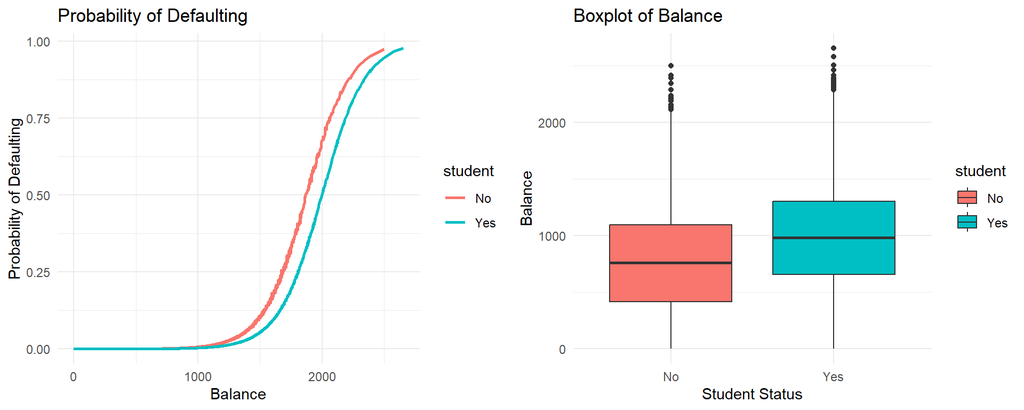

#### Misclassification rate

How many values does our model get right and how many get wrong? for that we can use a *confusion matrix* :

```r
# Get predicted probabilities
glm.probs <- predict(glm.fit, type = "response")

# Convert probabilities to binary predictions (threshold = 0.5)
glm.pred <- ifelse(glm.probs > 0.5, "Yes", "No")

# Print confusion matrix
print('Confusion Matrix')
```

```
[1] "Confusion Matrix"
```

```r
table(Default$default, glm.pred)
```

```
     glm.pred
        No  Yes
  No  9627   40
  Yes  228  105
```

```r
cat('misclassification rate: ', (228+40)/10000)
```

```
misclassification rate:  0.0268
```

But this values are over estimated because we are using the same data that we used to train our model, so this is the training error. As we already know, to get the real fit of our model we should train our model with a subset of data and test it with unseen data.

#### Null rate

Although this misclassification rate might seem very small, we need to take into consideration, that the data has a majority of ‘No’ in the response, so if we would fit every single value to ‘No’ without using any model, we would only get 333/10000 errors, so only 3.33% misclassification. This is called the *null rate*

Another way of looking at it would be seeing what percentage of No’s and Yes’s we have missclassified.

- For No’s we have missclassified 40 out of 9667 = 0.4%
- For Yes’s we have missclassified 228 out of 333 = 68.5%

#### Visualizing the relationship between variables

A way of checking the relationship between different predictors in our model is to visualize a scatter matrix using `pairs()`. We will use the `SAheart` dataset for this:

In this case we are not trying to predict the probability of getting a heart disease, we are going to assess the risk factors

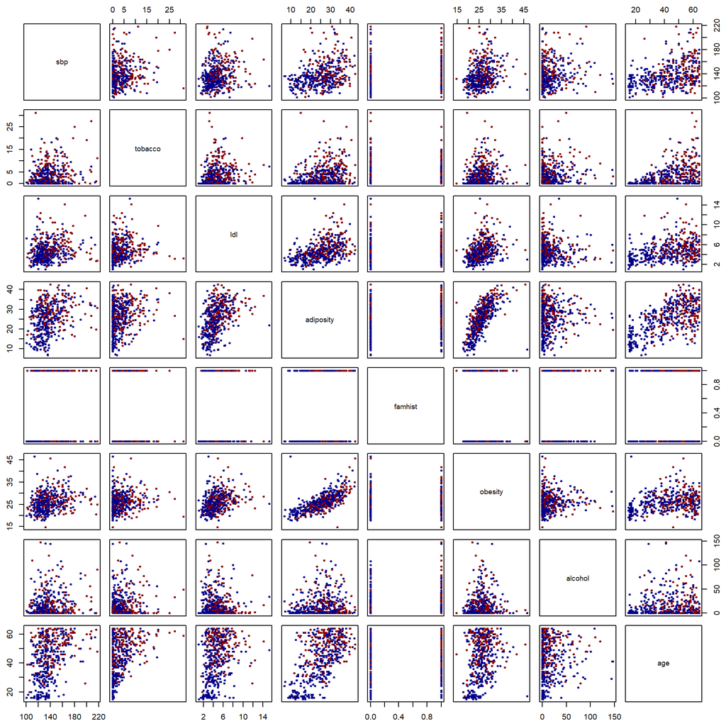

```r
# Load the SAheart dataset
library(bestglm)
data(SAheart)

# Select columns to include in the pairs plot (excluding 'typea')
SAheart_selected <- SAheart %>%
  dplyr::select(-c(typea)) %>%
  mutate(famhist = ifelse(famhist == "Present", 1, 0))

# Define colors based on 'chd'
color_chd <- ifelse(SAheart_selected$chd == 1, "darkred", "darkblue")

# Exclude the 'chd' column from the pair plot
SAheart_selected <- SAheart_selected %>%
  dplyr::select(-chd)

# Create the scatter plot matrix
pairs(SAheart_selected,
      col = color_chd,
      pch = 19,           # Use solid points
      cex = 0.5,          # Reduce point size
      labels = colnames(SAheart_selected),
      cex.labels = 0.9,   # Reduce label text size
      main = "Scatter-plot Matrix",
      oma = c(2, 2, 2, 2)) # Reduce outer margins
```

to fit a model for this data:

```r
heartfit <- glm(chd~.,data=SAheart, family=binomial)
summary(heartfit)
```

```
Call:
glm(formula = chd ~ ., family = binomial, data = SAheart)

Coefficients:
                 Estimate Std. Error z value   Pr(>|z|)
(Intercept)    -6.1507209  1.3082600  -4.701 0.00000258 ***
sbp             0.0065040  0.0057304   1.135   0.256374
tobacco         0.0793764  0.0266028   2.984   0.002847 **
ldl             0.1739239  0.0596617   2.915   0.003555 **
adiposity       0.0185866  0.0292894   0.635   0.525700
famhistPresent  0.9253704  0.2278940   4.061 0.00004896 ***
typea           0.0395950  0.0123202   3.214   0.001310 **
obesity        -0.0629099  0.0442477  -1.422   0.155095
alcohol         0.0001217  0.0044832   0.027   0.978350
age             0.0452253  0.0121298   3.728   0.000193 ***
---
Signif. codes:  0 '***' 0.001 '**' 0.01 '*' 0.05 '.' 0.1 ' ' 1

(Dispersion parameter for binomial family taken to be 1)

    Null deviance: 596.11  on 461  degrees of freedom
Residual deviance: 472.14  on 452  degrees of freedom
AIC: 492.14

Number of Fisher Scoring iterations: 5
```

Interestingly, obesity and alcohol does not show as significant and this is due to correlation.

Example:

We will begin by examining some numerical and graphical summaries of the Smarket data, which is part of the ISLR2 library. This data set consists of percentage returns for the S&P 500 stock index over 1,250 days, from the beginning of 2001 until the end of 2005. For each date, we have recorded the percentage returns for each of the five previous trading days, `lagone` through `lagfive`. We have also recorded volume (the number of shares traded on the previous day, in billions), Today (the percentage return on the date in question) and direction (whether the market was Up or Down on this date). Our goal is to predict direction (a qualitative response) using the other features.

```r
head(Smarket)
```

```
  Year   Lag1   Lag2   Lag3   Lag4   Lag5 Volume  Today Direction
1 2001  0.381 -0.192 -2.624 -1.055  5.010 1.1913  0.959        Up
2 2001  0.959  0.381 -0.192 -2.624 -1.055 1.2965  1.032        Up
3 2001  1.032  0.959  0.381 -0.192 -2.624 1.4112 -0.623      Down
4 2001 -0.623  1.032  0.959  0.381 -0.192 1.2760  0.614        Up
5 2001  0.614 -0.623  1.032  0.959  0.381 1.2057  0.213        Up
6 2001  0.213  0.614 -0.623  1.032  0.959 1.3491  1.392        Up
```

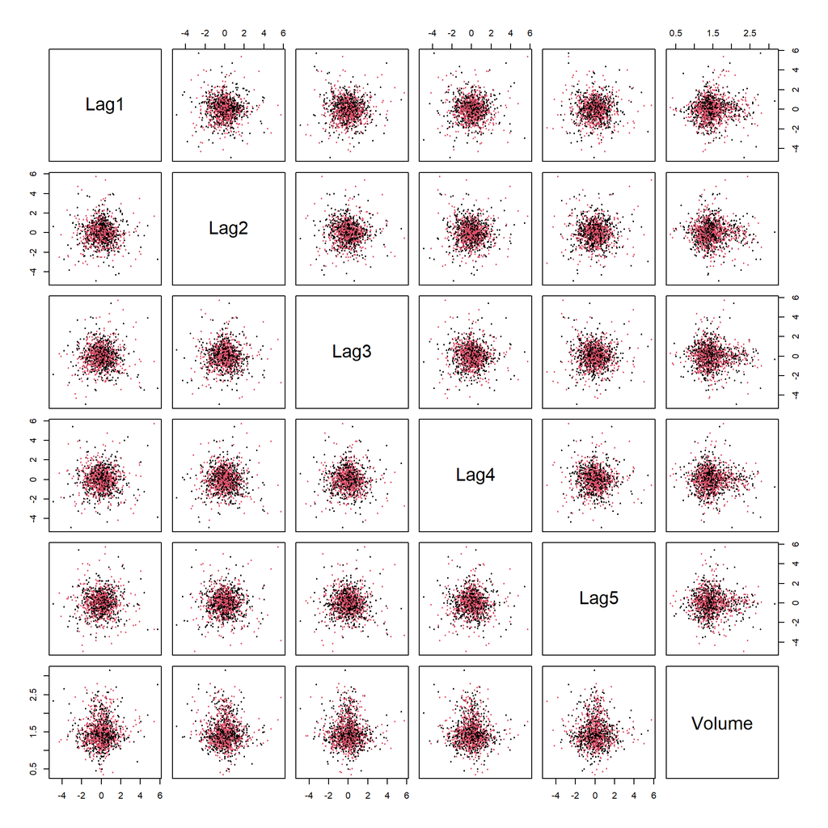

```r
pairs(Smarket[2:7], col = Smarket$Direction, pch = 20, cex = 0.5)
```

The pairs plot seem to not show a lot of correlation.

```r
glm.fits <- glm(
    Direction ~ Lag1 + Lag2 + Lag3 + Lag4 + Lag5 + Volume,
    data = Smarket, family = binomial
  )
summary(glm.fits)
```

```
Call:
glm(formula = Direction ~ Lag1 + Lag2 + Lag3 + Lag4 + Lag5 +
    Volume, family = binomial, data = Smarket)

Coefficients:
             Estimate Std. Error z value Pr(>|z|)
(Intercept) -0.126000   0.240736  -0.523    0.601
Lag1        -0.073074   0.050167  -1.457    0.145
Lag2        -0.042301   0.050086  -0.845    0.398
Lag3         0.011085   0.049939   0.222    0.824
Lag4         0.009359   0.049974   0.187    0.851
Lag5         0.010313   0.049511   0.208    0.835
Volume       0.135441   0.158360   0.855    0.392

(Dispersion parameter for binomial family taken to be 1)

    Null deviance: 1731.2  on 1249  degrees of freedom
Residual deviance: 1727.6  on 1243  degrees of freedom
AIC: 1741.6

Number of Fisher Scoring iterations: 3
```

The ’contrast()` function tells us what value of Direction is 0 and which one is 1:

```r
contrasts(Smarket$Direction)
```

```
     Up
Down  0
Up    1
```

The negative predictor in lag1, lag2 suggest that if the market had a positive return yesterday, then it is less likely to go up today, however, the $p$-value is large, so there is no clear association.

The null deviance and the residual deviance are very similar, which indicates that the model does not perform much better than just using the average.

The `predict()` function can be used to predict the probability that the market will go up, given the values of the predictors. The `type="response"` option tells R to output probabilities of the form $P(Y=1|X)$, as opposed to other information such as the logit. If no data set is supplied to the `predict()` function, then the probabilities are computed for the training data that was used to fit the logistic regression model. Here we have printed only the first ten probabilities. We know that these values correspond to the probability of the market going up, rather than down, because the `contrasts()` function indicates that `R` has created a dummy variable with a 1 for `Up`.

```r
glm.probs <- predict(glm.fits, type = "response")
glm.probs[1:10]
```

```
        1         2         3         4         5         6         7         8
0.5070841 0.4814679 0.4811388 0.5152224 0.5107812 0.5069565 0.4926509 0.5092292
        9        10
0.5176135 0.4888378
```

The first thing that calls our attention is that the values are very close to 50%, so the predictors are not very strong. In order to make a prediction as to whether the market will go up or down on a particular day, we must convert these predicted probabilities into class labels, `Up` or `Down`. The following two commands create a vector of class predictions based on whether the predicted probability of a market increase is greater than or less than $0.5$.

```r
glm.pred <- rep("Down", 1250)
glm.pred[glm.probs > .5] = "Up"
```

The first command creates a vector of 1,250 `Down` elements. The second line transforms to `Up` all of the elements for which the predicted probability of a market increase exceeds $0.5$. Given these predictions, the `table()` function can be used to produce a *confusion matrix* in order to determine how many observations were correctly or incorrectly classified.

```r
table(glm.pred, Smarket$Direction)
```

```
glm.pred Down  Up
    Down  145 141
    Up    457 507
```

```r
(507 + 145) / 1250
```

```
[1] 0.5216
```

```r
mean(glm.pred == Smarket$Direction)
```

```
[1] 0.5216
```

The diagonal elements of the confusion matrix indicate correct predictions, while the off-diagonals represent incorrect predictions. Hence our model correctly predicted that the market would go up on $507$ days and that it would go down on $145$ days, for a total of $507+145 = 652$ correct predictions. The `mean()` function can be used to compute the fraction of days for which the prediction was correct. In this case, logistic regression correctly predicted the movement of the market $52.2$% of the time.

At first glance, it appears that the logistic regression model is working a little better than random guessing. However, this result is misleading because we trained and tested the model on the same set of $1,250$ observations. In other words, $100\%-52.2\%=47.8\%$, is **the *training* error rate**. As we have seen previously, the training error rate is often overly optimistic -it tends to underestimate the test error rate-. In order to better assess the accuracy of the logistic regression model in this setting, we can fit the model using part of the data, and then examine how well it predicts the *held out* data. This will yield a more realistic error rate, in the sense that in practice we will be interested in our model’s performance not on the data that we used to fit the model, but rather on days in the future for which the market’s movements are unknown. To implement this strategy, we will first create a vector corresponding to the observations from 2001 through 2004. We will then use this vector to create a held out data set of observations from 2005:

```r
train <- (Smarket$Year < 2005)
Smarket.2005 <- Smarket[!train, ]
dim(Smarket.2005)
```

```
[1] 252   9
```

```r
Direction.2005 <- Smarket$Direction[!train]
```

We now fit a logistic regression model using only the subset of the observations that correspond to dates before 2005, using the subset argument. We then obtain predicted probabilities of the stock market going up for each of the days in our test set—that is, for the days in 2005.

```r
glm.fits <- glm(
    Direction ~ Lag1 + Lag2 + Lag3 + Lag4 + Lag5 + Volume,
    data = Smarket, family = binomial, subset = train
  )
glm.probs <- predict(glm.fits, Smarket.2005,
    type = "response")
```

Notice that we have trained and tested our model on two completely separate data sets: training was performed using only the dates before 2005, and testing was performed using only the dates in 2005. Finally, we compute the predictions for 2005 and compare them to the actual movements of the market over that time period.

```r
glm.pred <- rep("Down", 252)
glm.pred[glm.probs > .5] <- "Up"
table(glm.pred, Direction.2005)
```

```
        Direction.2005
glm.pred Down Up
    Down   77 97
    Up     34 44
```

```r
mean(glm.pred == Direction.2005)
```

```
[1] 0.4801587
```

and our test set error rate:

```r
mean(glm.pred != Direction.2005)
```

```
[1] 0.5198413
```

Suppose that we want to predict the returns associated with particular values. We do this using the predict() function.

```r
predict(glm.fits,
    newdata = data.frame(Lag1 = c(1.2, 1.5),  Lag2 = c(1.1, -0.8),  Lag3 = c(1.1, -0.8), Lag4 = c(1.1, -0.8), Lag5 = c(1.1, -0.8), Volume= c(10,100), type = "response"
  ))
```

```
         1          2
 -1.076397 -11.486641
```

### 1.1.4 Case-control sampling and logistic regression.

We know because medicine tells us, that the risk of heart disease in this type of population of South Africans is actually 5%. But in our dataset we used 160 cases (people with heart disease) and 302 controls. This results in an estimated proportion of $\tilde{\pi} = 0.35$, yet the prevalence of the heart disease is $\pi=0.05$

We can still use these data set to fit our model, and the model will be correct, but the constant term will be incorrect. We can correct the constant using a simple transformation.
$$\hat{\beta_0^*}=\hat{\beta_0}+log\frac{\pi}{1-\pi}-log\frac{\tilde{\pi}}{1-\tilde{\pi}}$$
This formula is a re-calibration or re-centering of the logistic regression intercept $\hat{\beta_0}$ where: - $\hat{\beta_0}$ is the original estimated intercept. - $\hat{\beta_0^*}$ is the adjusted intercept after re-calibration. - $\pi$ is the baseline probability in the population. - $\tilde{\pi}$ is the target probability or prevalence rate you are adjusting to.

This is an approach often followed in epidemiology because the cases that we want to study are rare, so we want to take them all, up to five or six times that number of controls is sufficient. Another example is in advertising, where the click-through ratio for an add is very low, we need usually hundreds or thousands of people that saw the add but did not click on it, for just a few clicks, so following this approach we can reduce our dataset and not include all the control data.

### 1.1.5 Multinomial regression

So far we have only considered two classes in the response, but we can extend the model to k number of classes:
$$Pr(Y = k \mid X = x) = \frac{e^{\beta_{k0} + \beta_{k1}x_1 + \cdots + \beta_{kp}x_p}}{1 + \sum_{l=1}^{K-1} e^{\beta_{l0} + \beta_{l1}x_1 + \cdots + \beta_{lp}x_p}}
\tag{6}$$

To do this, we first select a single class to serve as a baseline. The decision to treat one specific class as a baseline is unimportant. The coefficient estimates will differ between two fitted models to different baselines variables due to the differing choice of baseline, but the fitted values (predictions), the log odds between any pair of classes, and the other key model outputs will remain the same.

Although we can use multinomial regression for k values, it has its limitations: - When the classes are well separated, the parameter estimates for the logistic regression model are surprisingly unstable. - If n is small and the distribution of the predictors X is approximately normal in each of the classes, the linear discriminant model that we will see next is more stable than the logistic regression model.

## 1.2 Discriminant Analysis.

### 1.2.1 Linear Discriminant Analysis(LDA)

Linear discriminant analysis is popular when we have more than two response classes.

We can model de distribution of X in each of the classes separately and then use Bayes theorem to flip things around to get the probability of Y given X. When we use normal distributions for each class, this leads to linear or quadratic discriminant analysis.

#### Bayes theorem for classification.

$$P(Y=k \mid X=x) = \frac{Pr(X=x \mid Y=k) \times Pr(Y=k)}{Pr(X=x)}
\tag{7}$$

- Posterior Probability $P(Y=k X=x) $ this is the probability that the target variable Y is in class k given the observed data X=x
- Likelihood: $Pr(X=x \mid Y=k)$ this is the probability of observing the data X=x given that the variable Y is in class k.
- Prior Probability: $Pr(Y=k)$ This is the initial probability of class k before observing the data, it’s your prior belief about the class distribution.
- Marginal Likelihood: $Pr(X=x)$ this is the overall probability of observing the data X=x across all classes.

### 1.2.2 k-Nearest Neighbour classification

In theory we would always like to predict qualitative responses using the Bayes classifier. But for real data, we do not know the conditional distribution of Y given X, and so computing the Bayes classifier is impossible. The k-nearest neighbor classification uses distance to try to classify the predictions: Given a positive integer K and a test observation $x_0$, the KNN classifier first identifies the K points in the training data that are closest to x0, represented by $N_0$. It then estimates the conditional probability for class $j$ as the fraction of points in $N_0$ whose response values equal $j$:
$$P(Y=j|X=x_0)=\frac{1}{K}\sum_{i\epsilon N_0}I(y_i=j)
\tag{8}$$

The algorithm relies on a distance metric (commonly Euclidean distance) to measure the similarity between instances. The distance between two points $(x_1, y_1)$ and $(x_2, y_2)$ in a 2D space is calculated as: $d=(x_2-x_1)^2+(y_2-y_1)^2$

Choosing k: The parameter $k$ represents the number of nearest neighbors to consider when making a prediction. For example, if $k = 3$, the algorithm looks at the 3 closest training instances to the query point.

For classification, k-NN uses a majority voting mechanism. The class label that appears most frequently among the $k$ nearest neighbors is assigned to the query point.

k-NN is a non-parametric algorithm, meaning it makes no assumptions about the underlying data distribution. This makes it flexible but also computationally intensive, especially with large datasets.

Example:

We will need the library ‘class’ and work with the IRIS dataset. First we divide the dataset into training and test subsets and use the `knn` function to get the predicted values for the test dataset. We can use a confusion_matrix to see the successes and failures of the model guessing the species.

```r
set.seed(1)
sample <- sample(c(TRUE, FALSE), nrow(iris), replace=TRUE, prob=c(0.7, 0.3))
train <- iris[sample,1:4 ]
test <- iris[!sample,1:4 ]
species<- iris[sample,5]
specietest <- iris[!sample,5]
knn.pred<- class::knn(train,test,species,k=1)
table(knn.pred,specietest)
```

```
            specietest
knn.pred     setosa versicolor virginica
  setosa         16          0         0
  versicolor      0         16         1
  virginica       0          0        11
```

```r
mean(knn.pred ==specietest)
```

```
[1] 0.9772727
```

#### Linear Discriminant Analysis for one variable.

To classify Y at the value X=x we only need to see which of the $p_x(x)$ is the largest. For this we use the *discriminant score*

$$\delta_k(x) = x \frac{\mu_k}{\sigma^{2}} - \frac{\mu_k^2}{2\sigma^{2}}+ \log(\pi_k)
\tag{9}$$

Where $\pi$ is the prior probability

Note that $\delta_k(x)$ is a linear function of x

When the priors are different, we have take them into consideration and compare $\pi_k f_x(x)$

We usually don’t know the prior, so we have to estimate it looking at the data. The estimated prior in each class will be the total number of elements in that class divided by the total number of cases
$$\hat{\pi_k}=\frac{n_k}{n}$$

The mean of each class is calculated normally. The estimated variance is a bit more complex because it is not using the variance of each class but the *pooled variance estimate*

$$\hat{\sigma^2}= \frac{1}{n-K} \sum^K_{k=1} \sum_{y_i=k}(x_1-\hat{\mu_k})^2= \sum^K_{k=1}\frac{n_k-1}{n-K}\times\hat{\sigma^2_k}
\tag{10}$$

Where $\hat{\sigma^2_k}$ is the usual formula for the estimated variance in the kth class.
$$\frac{1}{n_k-1}\sum^N_{i:y_i=k}(x_i-\hat{\mu_k})^ 2$$
so basically what we are doing in the pooled variance is to calculate the variance for each of the classes and then do a weighted average of them.

### 1.2.3 Multivariate linear discrimination.

The discriminant score function for multivariate takes this quite complicated form:
$$\delta_k(x) = x^T\Sigma^{-1} \mu_k -\frac{1}{2}\mu_k^T\Sigma^{-1}\mu_k+ \log(\pi_k)
\tag{11}$$

Once we have the estimates for the different parameters $\hat{\delta}_k(x)$ we can turn these into estimates for class probabilities:
$$\hat{P_{r}}(Y = k | X = x) = \frac{e^{\hat{\delta_k} (x)}}{\sum_{l=1}^{K} e^{\hat{\delta_l}(x)}}
\tag{12}$$

With these estimates we will classify Y=k to the largest probability for the value of x we are interested in.

We can run a classification over the Default dataset that we already used in multiple logistic regression. To do so we use the function LDA from library MASS, but first we are going to check the levels of the response variable to know which value the reference (the first one):

```r
levels(Default$default)
```

```
[1] "No"  "Yes"
```

So our reference level is default= ‘No’

```r
LDA.fit = lda( default ~ income+balance+student, data=Default, )
LDA.fit
```

```
Call:
lda(default ~ income + balance + student, data = Default, )

Prior probabilities of groups:
    No    Yes
0.9667 0.0333

Group means:
      income   balance studentYes
No  33566.17  803.9438  0.2914037
Yes 32089.15 1747.8217  0.3813814

Coefficients of linear discriminants:
                      LD1
income      0.00000336731
balance     0.00224354109
studentYes -0.17466314059
```

```r
LDA.fit.p = predict(LDA.fit, newdata=Default[,2:4])
LDA.fit.Classes = predict(LDA.fit, newdata=Default[,2:4])$class
```

**How to interpret the results of the LDA**

- *Prior Probabilities of Groups*: These are the probabilities assigned to each class (No and Yes) before observing any data, based on the proportion of each class in the training data.
  - No: 0.9667 (96.67% of the data is in the “No” category)
  - Yes: 0.0333 (3.33% of the data is in the “Yes” category)
- *Group Means*: These are the mean values of each predictor variable for each class.
- *Coefficients of Linear Discriminants*: These coefficients are used to form the linear discriminant functions (LD1 in this case). The linear discriminant function combines the predictor variables to maximize the separation between the classes. Larger absolute values of coefficients indicate more significant contributions to the discriminant function.

The negative coefficient of the Student(Yes) indicates that being a Student reduces the possibility of defaulting = ‘yes’.

In a two-class LDA model with reference level A, a positive coefficient for a predictor indicates that an increase in that predictor increases the discriminant score. A higher discriminant score makes it more likely for the observation to be classified as B rather than A.

Conversely, a negative coefficient indicates that an increase in the predictor decreases the discriminant score, making it more likely for the observation to be classified as A.

In this case we only have a LDF (LD1), but with more classess we will get more. The number of LDFs is always one less than the number of classes.

**Histogram of Linear Discriminants**: We can also use plots to see the overlapping of our groups: This plot shows a histogram of the discriminant function values for each class. The histograms should ideally show distinct peaks for each class, indicating good separation.

Overlapping histograms suggest some misclassification, as the discriminant function values are not clearly separated.

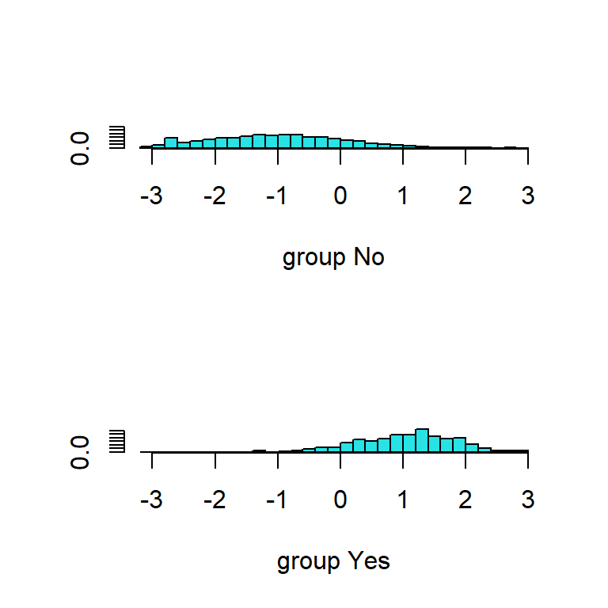

```r
plot(LDA.fit)
```

create a confusion matrix:

```r
table(Default$default,LDA.fit.Classes)
```

```
     LDA.fit.Classes
        No  Yes
  No  9645   22
  Yes  254   79
```

And as before, we can use the confusion matrix to calculate our misclassification rate:

```r
cat('misclassification rate: ', (254+22)/10000)
```

```
misclassification rate:  0.0276
```

For No’s we have missclassified 22 out of 9667 = 0.2% this is our *False positive rate* For Yes’s we have missclassified 254 out of 333 = 76.3% this is our *False negative rate*

We can also use the function `confusionMatrix()` from the package `caret` to create and analyse the results. It takes two parameters the first one is the predicted values and the second one the real values (reference)

```r
# Create confusion matrix
confusion_matrix <- caret::confusionMatrix(data=factor(LDA.fit.Classes), reference=Default$default)

print(confusion_matrix)
```

```
Confusion Matrix and Statistics

          Reference
Prediction   No  Yes
       No  9645  254
       Yes   22   79

               Accuracy : 0.9724
                 95% CI : (0.969, 0.9755)
    No Information Rate : 0.9667
    P-Value [Acc > NIR] : 0.0006128

                  Kappa : 0.354

 Mcnemar's Test P-Value : < 0.00000000000000022

            Sensitivity : 0.9977
            Specificity : 0.2372
         Pos Pred Value : 0.9743
         Neg Pred Value : 0.7822
             Prevalence : 0.9667
         Detection Rate : 0.9645
   Detection Prevalence : 0.9899
      Balanced Accuracy : 0.6175

       'Positive' Class : No
```

**Interpreting the results of the confusion matrix**

- *Accuracy*: It measures the overall correctness of the model. 97.24% of the predictions are correct.
- *95% CI (Confidence Interval)*: It provides a range within which the true accuracy lies with 95% confidence.
- *No Information Rate (NIR)*:It represents the accuracy if the model always predicted the majority class (No).
- $p$-value [Acc > NIR]: This $p$-value tests if the accuracy is significantly better than the NIR.
- *Kappa*: It measures the agreement between the observed and predicted classifications, adjusted for chance. Values close to 1 indicate better agreement.
- *Mcnemar’s Test* $p$-value: Tests if there is a significant difference between the number of false positives and false negatives.

Class-Specific Metrics:

- *Sensitivity (Recall)*:Proportion of actual positives correctly identified.
- *Specificity*: Proportion of actual negatives correctly identified.
- *Positive Predictive Value (Precision)*: Proportion of positive results that are true positives.
- *Negative Predictive Value*: Proportion of negative results that are true negatives.
- *Prevalence*: Proportion of the actual positive cases in the dataset.
- *Detection Rate*: Proportion of actual positives correctly identified by the model.
- *Detection Prevalence*:Proportion of the predicted positives out of the total predictions.
- *Balanced Accuracy*: It’s the average of sensitivity and specificity, providing a balanced measure for imbalanced datasets.

Summary: The model has a high overall accuracy (97.24%), but its specificity (23.72%) is low, indicating it struggles to correctly identify the negative class (Yes).

The high sensitivity (99.77%) suggests it’s good at identifying the majority class (No), but at the cost of false positives.

Adjusting the model or the decision threshold can help to balance sensitivity and specificity better.

ROC Curve: We can use A ROC plot and AUC (Area under the curve) to summarize the overall performance of our model. A higher AUC is desired.

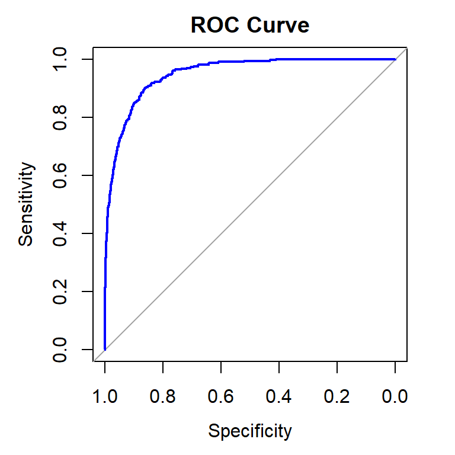

```r
# Fit the LDA model
LDA.fit <- lda(default ~ income + balance + student, data = Default)

# Get predicted probabilities
LDA.fit.prob <- predict(LDA.fit, newdata = Default[, 2:4])$posterior[, 2]

# Generate ROC curve
roc_curve <- roc(Default$default, LDA.fit.prob)

# Plot ROC curve
plot(roc_curve, main = "ROC Curve", col = "blue", lwd = 2)
```

```r
# Add AUC to the plot
auc(roc_curve)
```

```
Area under the curve: 0.9495
```

The *Receiver Operating Characteristic* (ROC) curve is a graphical representation used to evaluate the performance of a classification model. It plots the True Positive Rate (Sensitivity) against the False Positive Rate (1-Specificity) at various threshold settings.

- *True Positive Rate* (TPR): Also known as sensitivity, it measures the proportion of actual positives correctly identified by the model.
- *False Positive Rate* (FPR): It measures the proportion of actual negatives incorrectly identified as positives by the model.

The ROC curve helps visualize the trade-off between sensitivity and specificity for different threshold values. It is also used to compare Models: By comparing the ROC curves of different models, you can assess which model performs better.

*The Area Under the ROC Curve* (AUC) is a single scalar value that summarizes the performance of a classification model. - AUC = 1: Perfect model (perfectly separates positive and negative classes). - AUC = 0.5: Random model (no better than random guessing). - AUC < 0.5: Worse than random guessing.

Use of AUC: - Model Comparison: A higher AUC value indicates a better-performing model. - Robustness: AUC is insensitive to the threshold chosen for classification, providing a more robust evaluation metric.

In essence, the ROC curve and AUC provide a comprehensive way to evaluate and compare classification models, ensuring you pick the most accurate and reliable one.

Following what we see in the plot we think that a prior of 0.9 and 0.1 can be better, so we adjust our model accordingly:

```r
# Fit LDA model with adjusted prior probabilities
LDA.fit <- lda(default ~ income + balance + student, data = Default, prior = c(0.9, 0.1))

# Predict and evaluate
LDA.fit.Classes <- predict(LDA.fit, newdata = Default[, 2:4])$class
confusion_matrix <- caret::confusionMatrix(factor(LDA.fit.Classes), Default$default)

# Print confusion matrix
print('Confusion Matrix')
```

```
[1] "Confusion Matrix"
```

```r
print(confusion_matrix)
```

```
Confusion Matrix and Statistics

          Reference
Prediction   No  Yes
       No  9496  157
       Yes  171  176

               Accuracy : 0.9672
                 95% CI : (0.9635, 0.9706)
    No Information Rate : 0.9667
    P-Value [Acc > NIR] : 0.4041

                  Kappa : 0.5007

 Mcnemar's Test P-Value : 0.4729

            Sensitivity : 0.9823
            Specificity : 0.5285
         Pos Pred Value : 0.9837
         Neg Pred Value : 0.5072
             Prevalence : 0.9667
         Detection Rate : 0.9496
   Detection Prevalence : 0.9653
      Balanced Accuracy : 0.7554

       'Positive' Class : No
```

```r
# Extract the confusion matrix values
cm <- confusion_matrix$table

# Calculate False Positive Rate (FPR) and False Negative Rate (FNR)
false_positive_rate <- cm[2, 1] / sum(cm[, 1])
false_negative_rate <- cm[1, 2] / sum(cm[, 2])

# Print the rates
cat('False Positive Rate: ', false_positive_rate, '\n')
```

```
False Positive Rate:  0.01768905
```

```r
cat('False Negative Rate: ', false_negative_rate, '\n')
```

```
False Negative Rate:  0.4714715
```

Example with three classes:

As an example we can see Fisher’s Iris dataset. It has 3 classes (Iris Species) and uses 4 different parameters to classify the different species: Sepal Length, Sepal Width, Petal Length and Petal Width. If we plot each variable against each other using `pairs()` we can see that we can actually see quite a clear differentiation between the species using these variables.

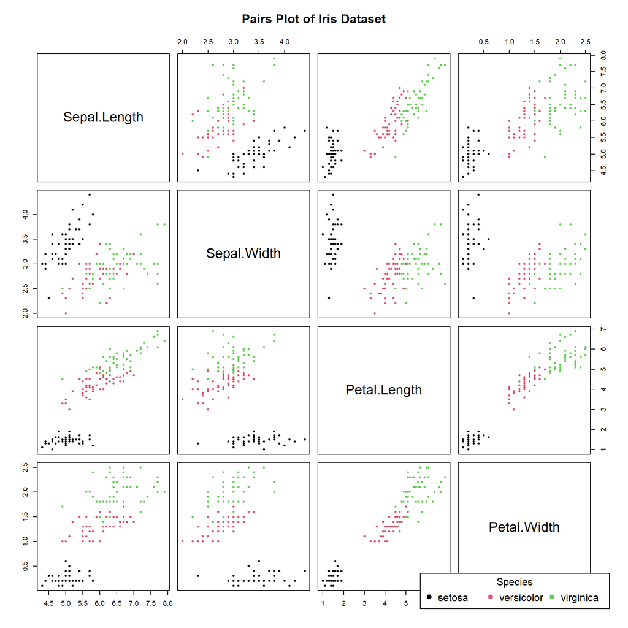

We are going to fit a model for our iris data and see how well it works predicting the species.

```r
LDA.fit = lda( Species ~ Sepal.Length + Sepal.Width + Petal.Length + Petal.Width, iris)
LDA.fit
```

```
Call:
lda(Species ~ Sepal.Length + Sepal.Width + Petal.Length + Petal.Width,
    data = iris)

Prior probabilities of groups:
    setosa versicolor  virginica
 0.3333333  0.3333333  0.3333333

Group means:
           Sepal.Length Sepal.Width Petal.Length Petal.Width
setosa            5.006       3.428        1.462       0.246
versicolor        5.936       2.770        4.260       1.326
virginica         6.588       2.974        5.552       2.026

Coefficients of linear discriminants:
                    LD1         LD2
Sepal.Length  0.8293776 -0.02410215
Sepal.Width   1.5344731 -2.16452123
Petal.Length -2.2012117  0.93192121
Petal.Width  -2.8104603 -2.83918785

Proportion of trace:
   LD1    LD2
0.9912 0.0088
```

We see that now we have to LDFs LD1 and LD2.

*Proportion of Trace*: The proportion of trace tells you how much of the total between-class variance each linear discriminant function explains.

In this case:

- LD1: Explains 99.12% of the variance.
- LD2: Explains 0.88% of the variance.

So, LD1 is the primary driver for separating the species in the iris dataset, while LD2 adds a minor amount of additional discrimination.

Now we are going to perform the classification:

```r
LDA.fit.C = predict(LDA.fit, newdata=iris[,c(1,2,3,4)])$class

head(LDA.fit.C)
```

```
[1] setosa setosa setosa setosa setosa setosa
Levels: setosa versicolor virginica
```

We can quickly create a confusion matrix using table:

```r
table(iris$Species, LDA.fit.C)
```

```
            LDA.fit.C
             setosa versicolor virginica
  setosa         50          0         0
  versicolor      0         48         2
  virginica       0          1        49
```

As we have seen before we can also use the confusion matrix function from the package caret:

```r
caret::confusionMatrix(data=LDA.fit.C, reference=iris$Species )
```

```
Confusion Matrix and Statistics

            Reference
Prediction   setosa versicolor virginica
  setosa         50          0         0
  versicolor      0         48         1
  virginica       0          2        49

Overall Statistics

               Accuracy : 0.98
                 95% CI : (0.9427, 0.9959)
    No Information Rate : 0.3333
    P-Value [Acc > NIR] : < 0.00000000000000022

                  Kappa : 0.97

 Mcnemar's Test P-Value : NA

Statistics by Class:

                     Class: setosa Class: versicolor Class: virginica
Sensitivity                 1.0000            0.9600           0.9800
Specificity                 1.0000            0.9900           0.9800
Pos Pred Value              1.0000            0.9796           0.9608
Neg Pred Value              1.0000            0.9802           0.9899
Prevalence                  0.3333            0.3333           0.3333
Detection Rate              0.3333            0.3200           0.3267
Detection Prevalence        0.3333            0.3267           0.3400
Balanced Accuracy           1.0000            0.9750           0.9800
```

Lastly, we can create an LDA plot to view the linear discriminants of the model and visualize how well it separated the three different species in our dataset:

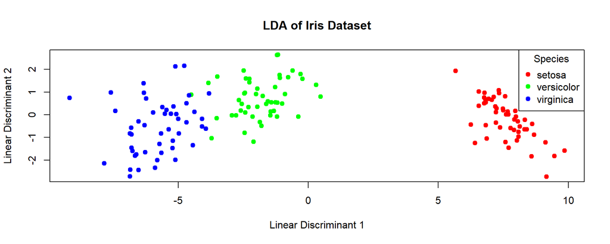

```r
# Predict the LDA values
lda.pred <- predict(LDA.fit, newdata=iris[,c(1,2,3,4)])$x

# Combine the LDA values with the original dataset
lda.data <- data.frame(lda.pred, Species = iris$Species)

# Define colors for each species
species_colors <- c(setosa = "red", versicolor = "green", virginica = "blue")

# Plot the LDA results using base R plot
plot(lda.data$LD1, lda.data$LD2, col = species_colors[lda.data$Species],
     pch = 19, xlab = "Linear Discriminant 1", ylab = "Linear Discriminant 2",
     main = "LDA of Iris Dataset")

# Add a legend
legend("topright", legend = levels(iris$Species),
       col = species_colors, pch = 19, title = "Species")
```

### 1.2.4 Quadratic Discriminant Analysis (QDA).

So far we have seen how to use discriminant analysis for a normal distribution, with the same variance for each class. If the distribution is still normal but the variance for each class is different, we use *quadratic discriminant analysis* The formula for the discriminant score was quite simple for the linear discriminant analysis because the quadratic terms were cancelling each other, but now, because $\Sigma_k$ are different, we cannot apply that cancellation.
$$\delta_k(x) = -\frac{1}{2}(x-\mu_k)^T\Sigma_k^{-1}(x-\mu_k) + \log{\pi_k} - \frac{1}{2}\log{|\Sigma_k|}
\tag{13}$$

Where - $\Sigma_k$ represents the covariance matrix for class (k). It describes the spread and orientation of the data points in class (k). - $\pi_k$: This is the prior probability of class (k). It represents the proportion of data points that belong to class (k) in the training dataset.

Quadratic discriminant analysis is good when the number of features is not high, because you need to estimate the covariance matrices.

Example:

We are going to use the iris dataset to perform quadratic Discriminant Analisys. We will split the dataset into training and testing sets:

```r
str(iris)
```

```
'data.frame':   150 obs. of  5 variables:
 $ Sepal.Length: num  5.1 4.9 4.7 4.6 5 5.4 4.6 5 4.4 4.9 ...
 $ Sepal.Width : num  3.5 3 3.2 3.1 3.6 3.9 3.4 3.4 2.9 3.1 ...
 $ Petal.Length: num  1.4 1.4 1.3 1.5 1.4 1.7 1.4 1.5 1.4 1.5 ...
 $ Petal.Width : num  0.2 0.2 0.2 0.2 0.2 0.4 0.3 0.2 0.2 0.1 ...
 $ Species     : Factor w/ 3 levels "setosa","versicolor",..: 1 1 1 1 1 1 1 1 1 1 ...
```

```r
set.seed(1)
sample <- sample(c(TRUE, FALSE), nrow(iris), replace=TRUE, prob=c(0.7, 0.3))
train <- iris[sample, ]
test <- iris[!sample, ]
```

and now we use the `qda` function from the MASS package to fit the model over the training data:

```r
model <- qda(Species ~ ., data=train)
print(model)
```

```
Call:
qda(Species ~ ., data = train)

Prior probabilities of groups:
    setosa versicolor  virginica
 0.3207547  0.3207547  0.3584906

Group means:
           Sepal.Length Sepal.Width Petal.Length Petal.Width
setosa         4.982353    3.411765     1.482353   0.2411765
versicolor     5.994118    2.794118     4.358824   1.3676471
virginica      6.636842    2.973684     5.592105   2.0552632
```

*Prior probabilities of group*: These represent the proportions of each Species in the training set. For example, 35.8% of all observations in the training set were of species virginica.

*Group means*: These display the mean values for each predictor variable for each species. As ususal, to use the model to get the fitted values we use `predict`

```r
predictions <- predict(model, test)
names(predictions)
```

```
[1] "class"     "posterior"
```

Predict returns a list with two variables: - *class*: the predicted class - *Posterior*: the posterior probability that an observation belong to each class.

```r
head(predictions$class)
```

```
[1] setosa setosa setosa setosa setosa setosa
Levels: setosa versicolor virginica
```

```r
head(predictions$posterior)
```

```
   setosa                                  versicolor
4       1 0.00000000000000000007224769747310848916691
6       1 0.00000000000000000000000006209196139412465
7       1 0.00000000000000000000124833703395775206884
15      1 0.00000000000000000000000000000000002319705
17      1 0.00000000000000000000000000001396840155918
18      1 0.00000000000000000000000075811654693801403
                                                    virginica
4  0.00000000000000000000000000001642236497450937561309522450
6  0.00000000000000000000000000000000000008550910860907731162
7  0.00000000000000000000000000000008132699523077754852687371
15 0.00000000000000000000000000000000000000000000000005094803
17 0.00000000000000000000000000000000000000000095865040481277
18 0.00000000000000000000000000000000000086113205635398140910
```

We can use the following code to see what percentage of observations the QDA model correctly predicted:

```r
mean(predictions$class==test$Species)
```

```
[1] 1
```

And we create a confusion matrix to see the results:

```r
table(predictions$class, test$Species)
```

```
             setosa versicolor virginica
  setosa         16          0         0
  versicolor      0         16         0
  virginica       0          0        12
```

### 1.2.5 Naive Bayes

Naive Bayes is best used when the number of features is high because it does not require to calculate the covariance matrices. It assumes that the features are independent in each class, this means your predictor variables are independent, which is almost never true for real data. Despite the strong assumptions that it does, naive Bayes often produces good classification results.

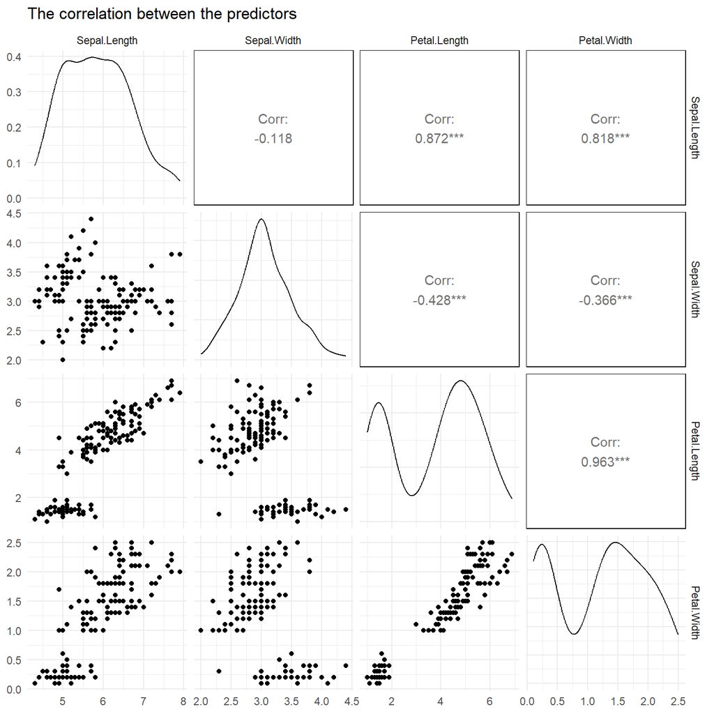

```r
GGally::ggpairs(iris[-5], title = "The correlation between the predictors")
```

We are going to split the data for the train and the test:

```r
set.seed(1)
sample <- sample(c(TRUE, FALSE), nrow(iris), replace=TRUE, prob=c(0.7, 0.3))
train <- iris[sample, ]
test <- iris[!sample, ]
```

We will need the library `naivebayes` for fitting the model:

```r
naive.fit <- naivebayes::naive_bayes(Species ~., data=train)
naive.fit
```

```
================================= Naive Bayes ==================================

Call:
naive_bayes.formula(formula = Species ~ ., data = train)

--------------------------------------------------------------------------------

Laplace smoothing: 0

--------------------------------------------------------------------------------

A priori probabilities:

    setosa versicolor  virginica
 0.3207547  0.3207547  0.3584906

--------------------------------------------------------------------------------

Tables:

--------------------------------------------------------------------------------
:: Sepal.Length (Gaussian)
--------------------------------------------------------------------------------

Sepal.Length    setosa versicolor virginica
        mean 4.9823529  5.9941176 6.6368421
        sd   0.3242433  0.4811232 0.7049712

--------------------------------------------------------------------------------
:: Sepal.Width (Gaussian)
--------------------------------------------------------------------------------

Sepal.Width    setosa versicolor virginica
       mean 3.4117647  2.7941176 2.9736842
       sd   0.4043436  0.3113423 0.3422376

--------------------------------------------------------------------------------
:: Petal.Length (Gaussian)
--------------------------------------------------------------------------------

Petal.Length    setosa versicolor virginica
        mean 1.4823529  4.3588235 5.5921053
        sd   0.1849989  0.4120295 0.6055516

--------------------------------------------------------------------------------
:: Petal.Width (Gaussian)
--------------------------------------------------------------------------------

Petal.Width    setosa versicolor virginica
       mean 0.2411765  1.3676471 2.0552632
       sd   0.1183668  0.1804382 0.2698321

--------------------------------------------------------------------------------
```

Now we can use the model to predict values using the test data subset and create a confusion matrix

```r
predictions <- predict(naive.fit, test)

(confusion_matrix<- table(predictions,test$Species))
```

```
predictions  setosa versicolor virginica
  setosa         16          0         0
  versicolor      0         16         1
  virginica       0          0        11
```

```r
(accuracy<- sum(diag(confusion_matrix))/sum(confusion_matrix))
```

```
[1] 0.9772727
```

:::